# Exo2_MaxLikelihood_correc

```python
import numpy as np
import matplotlib.pyplot as plt
```

## Exercice 2 : maximum de vraisemblance

### QUESTION 2.1 :

Tirer 10 fois une pièce à pile ou face et modéliser les résultats obtenus comme ceux d'une variable aléatoire X qui vaut X_i=0 si on a pile et X_i=1 si on a face.

Calculez le maximum de vraisemblance du paramètre p d'un loi de Bernoulli qui modéliserait le problème. Pour y arriver, différentes valeures possibles de p seront testées et le p retenu sera celui qui a la plus grande vraisemblance.

- Vérifier empiriquement comment évolue ce maximum de vraisemblance si l'on effectue de plus en plus de tirages
- Que se passe-t-il quand il y a trop de tirages ? Représenter la log-vraisemblance plutot que la vraisemblance dans ce cas.

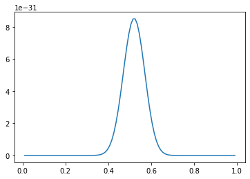

```python
NbTirages=100
NbPiles = np.random.randn(NbTirages) > 0
NbPiles = np.sum(NbPiles)
NbFaces=NbTirages-NbPiles


PossibleValuesForP=np.linspace(0.01,0.99,100)

def vraisemblance(n_pile, n_face, p):
    return p**n_pile * (1-p)**n_face

CorrespondingLikelihood = [vraisemblance(NbPiles, NbFaces, p) for p in PossibleValuesForP]

plt.plot(PossibleValuesForP,CorrespondingLikelihood)
plt.show()
```

### QUESTION 2.2 :

Vérifier empiriquement comment évolue ce maximum de vraisemblance si l'on effectue de plus en plus de tirages. Pour éviter de tirer des centaines de fois à pile ou face, vous pourrez juste modifier *NbTirages¨et* NbPiles *dans le code, puis voir le comportement de la courbe* plt.plot(PossibleValuesForP,CorrespondingLikelihood)*.

### QUESTION 2.3 :

Que se passe-t-il quand il y a trop de tirages ? Représenter la log-vraisemblance plutot que la vraisemblance dans ce cas.

### REPONSE 2.3 :

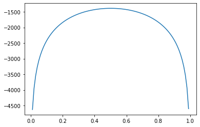

```python
NbTirages=2000
NbPiles = np.random.randn(NbTirages) > 0
NbPiles = np.sum(NbPiles)
NbFaces=NbTirages-NbPiles


PossibleValuesForP=np.linspace(0.01,0.99,100)

def log_vraisemblance(n_pile, n_face, p):
    return n_pile*np.log(p) + n_face*np.log(1-p)

CorrespondingLikelihood = [log_vraisemblance(NbPiles, NbFaces, p) for p in PossibleValuesForP]

plt.plot(PossibleValuesForP,CorrespondingLikelihood)
plt.show()
```